# Starbucks Capstone Challenge

### Introduction

This data set contains simulated data that mimics customer behavior on the Starbucks rewards mobile app. Once every few days, Starbucks sends out an offer to users of the mobile app. An offer can be merely an advertisement for a drink or an actual offer such as a discount or BOGO (buy one get one free). Some users might not receive any offer during certain weeks.

Not all users receive the same offer, and that is the challenge to solve with this data set.

Your task is to combine transaction, demographic and offer data to determine which demographic groups respond best to which offer type. This data set is a simplified version of the real Starbucks app because the underlying simulator only has one product whereas Starbucks actually sells dozens of products.

Every offer has a validity period before the offer expires. As an example, a BOGO offer might be valid for only 5 days. You'll see in the data set that informational offers have a validity period even though these ads are merely providing information about a product; for example, if an informational offer has 7 days of validity, you can assume the customer is feeling the influence of the offer for 7 days after receiving the advertisement.

You'll be given transactional data showing user purchases made on the app including the timestamp of purchase and the amount of money spent on a purchase. This transactional data also has a record for each offer that a user receives as well as a record for when a user actually views the offer. There are also records for when a user completes an offer.

Keep in mind as well that someone using the app might make a purchase through the app without having received an offer or seen an offer.

### Example

To give an example, a user could receive a discount offer buy 10 dollars get 2 off on Monday. The offer is valid for 10 days from receipt. If the customer accumulates at least 10 dollars in purchases during the validity period, the customer completes the offer.

However, there are a few things to watch out for in this data set. Customers do not opt into the offers that they receive; in other words, a user can receive an offer, never actually view the offer, and still complete the offer. For example, a user might receive the "buy 10 dollars get 2 dollars off offer", but the user never opens the offer during the 10 day validity period. The customer spends 15 dollars during those ten days. There will be an offer completion record in the data set; however, the customer was not influenced by the offer because the customer never viewed the offer.

### Cleaning

This makes data cleaning especially important and tricky.

You'll also want to take into account that some demographic groups will make purchases even if they don't receive an offer. From a business perspective, if a customer is going to make a 10 dollar purchase without an offer anyway, you wouldn't want to send a buy 10 dollars get 2 dollars off offer. You'll want to try to assess what a certain demographic group will buy when not receiving any offers.

### Final Advice

Because this is a capstone project, you are free to analyze the data any way you see fit. For example, you could build a machine learning model that predicts how much someone will spend based on demographics and offer type. Or you could build a model that predicts whether or not someone will respond to an offer. Or, you don't need to build a machine learning model at all. You could develop a set of heuristics that determine what offer you should send to each customer (i.e., 75 percent of women customers who were 35 years old responded to offer A vs 40 percent from the same demographic to offer B, so send offer A).

# Data Sets

The data is contained in three files:

- portfolio.json - containing offer ids and meta data about each offer (duration, type, etc.)
- profile.json - demographic data for each customer
- transcript.json - records for transactions, offers received, offers viewed, and offers completed

Here is the schema and explanation of each variable in the files:

**portfolio.json**

- id (string) - offer id
- offer_type (string) - type of offer ie BOGO, discount, informational
- difficulty (int) - minimum required spend to complete an offer
- reward (int) - reward given for completing an offer
- duration (int) - time for offer to be open, in days
- channels (list of strings)

**profile.json**

- age (int) - age of the customer
- became_member_on (int) - date when customer created an app account
- gender (str) - gender of the customer (note some entries contain 'O' for other rather than M or F)
- id (str) - customer id
- income (float) - customer's income

**transcript.json**

- event (str) - record description (ie transaction, offer received, offer viewed, etc.)
- person (str) - customer id
- time (int) - time in hours since start of test. The data begins at time t=0
- value - (dict of strings) - either an offer id or transaction amount depending on the record

**Note:** If you are using the workspace, you will need to go to the terminal and run the command `conda update pandas` before reading in the files. This is because the version of pandas in the workspace cannot read in the transcript.json file correctly, but the newest version of pandas can. You can access the termnal from the orange icon in the top left of this notebook.

You can see how to access the terminal and how the install works using the two images below. First you need to access the terminal:

[figure not shown]

Then you will want to run the above command:

[figure not shown]

Finally, when you enter back into the notebook (use the jupyter icon again), you should be able to run the below cell without any errors.

```python
import pandas as pd
import numpy as np
import math
import json
import seaborn as sns
import datetime
import pickle
import matplotlib.pyplot as plt
from sklearn.preprocessing import MinMaxScaler
% matplotlib inline

#setting sns
sns.set_style("darkgrid")

# read in the json files
portfolio = pd.read_json('data/portfolio.json', orient='records', lines=True)
profile = pd.read_json('data/profile.json', orient='records', lines=True)
transcript = pd.read_json('data/transcript.json', orient='records', lines=True)
```

# Data Exploration

```python
#shapes of dataframes
print(portfolio.shape)
print(profile.shape)
print(transcript.shape)
```

```
(10, 6)
(17000, 5)
(306534, 4)
```

### 1. portfolio.json

```python
portfolio.head()
```

|  | channels | difficulty | duration | id | offer_type | reward |
| --- | --- | --- | --- | --- | --- | --- |
| 0 | [email, mobile, social] | 10 | 7 | ae264e3637204a6fb9bb56bc8210ddfd | bogo | 10 |
| 1 | [web, email, mobile, social] | 10 | 5 | 4d5c57ea9a6940dd891ad53e9dbe8da0 | bogo | 10 |
| 2 | [web, email, mobile] | 0 | 4 | 3f207df678b143eea3cee63160fa8bed | informational | 0 |
| 3 | [web, email, mobile] | 5 | 7 | 9b98b8c7a33c4b65b9aebfe6a799e6d9 | bogo | 5 |
| 4 | [web, email] | 20 | 10 | 0b1e1539f2cc45b7b9fa7c272da2e1d7 | discount | 5 |

```python
portfolio.isna().sum()
```

```
channels      0
difficulty    0
duration      0
id            0
offer_type    0
reward        0
dtype: int64
```

```python
portfolio.offer_type.unique()
```

```
array(['bogo', 'informational', 'discount'], dtype=object)
```

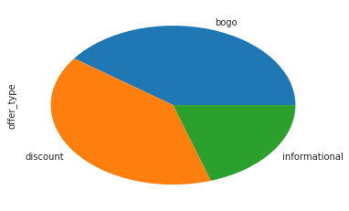

```python
portfolio.offer_type.value_counts().plot.pie()
```

```python
portfolio.id.nunique()
```

```
10
```

```python
portfolio.info()
```

```
<class 'pandas.core.frame.DataFrame'>
RangeIndex: 10 entries, 0 to 9
Data columns (total 6 columns):
channels      10 non-null object
difficulty    10 non-null int64
duration      10 non-null int64
id            10 non-null object
offer_type    10 non-null object
reward        10 non-null int64
dtypes: int64(3), object(3)
memory usage: 560.0+ bytes
```

```python
portfolio.describe()
```

|  | difficulty | duration | reward |
| --- | --- | --- | --- |
| count | 10.000000 | 10.000000 | 10.000000 |
| mean | 7.700000 | 6.500000 | 4.200000 |
| std | 5.831905 | 2.321398 | 3.583915 |
| min | 0.000000 | 3.000000 | 0.000000 |
| 25% | 5.000000 | 5.000000 | 2.000000 |
| 50% | 8.500000 | 7.000000 | 4.000000 |
| 75% | 10.000000 | 7.000000 | 5.000000 |
| max | 20.000000 | 10.000000 | 10.000000 |

#### Insights from portfolio.json

- The dataset has 6 columns and 10 rows.
- This dataset has no null values.
- There are three types of offers : 'bogo', 'informational' and 'discount'.
- channels column needs to be processed.
- 'duration' should be converted into hours as 'time' in transcript.json is also in hours.

### 2. profile.json

```python
profile.head()
```

|  | age | became_member_on | gender | id | income |
| --- | --- | --- | --- | --- | --- |
| 0 | 118 | 20170212 | None | 68be06ca386d4c31939f3a4f0e3dd783 | NaN |
| 1 | 55 | 20170715 | F | 0610b486422d4921ae7d2bf64640c50b | 112000.0 |
| 2 | 118 | 20180712 | None | 38fe809add3b4fcf9315a9694bb96ff5 | NaN |
| 3 | 75 | 20170509 | F | 78afa995795e4d85b5d9ceeca43f5fef | 100000.0 |
| 4 | 118 | 20170804 | None | a03223e636434f42ac4c3df47e8bac43 | NaN |

```python
profile.isna().sum()
```

```
age                    0
became_member_on       0
gender              2175
id                     0
income              2175
dtype: int64
```

```python
np.sum(profile['age'] == 118)
```

```
2175
```

```python
profile.age.describe()
```

```
count    17000.000000
mean        62.531412
std         26.738580
min         18.000000
25%         45.000000
50%         58.000000
75%         73.000000
max        118.000000
Name: age, dtype: float64
```

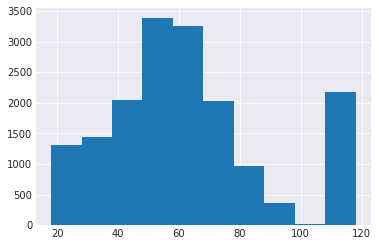

```python
profile.age.hist()
```

```python
profile.income.describe()
```

```
count     14825.000000
mean      65404.991568
std       21598.299410
min       30000.000000
25%       49000.000000
50%       64000.000000
75%       80000.000000
max      120000.000000
Name: income, dtype: float64
```

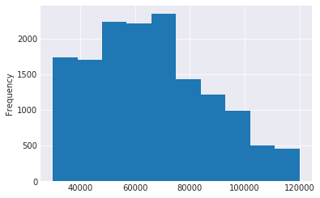

```python
profile.income.plot.hist()
```

```python
profile.gender.unique()
```

```
array([None, 'F', 'M', 'O'], dtype=object)
```

```python
profile.gender.value_counts()
```

```
M    8484
F    6129
O     212
Name: gender, dtype: int64
```

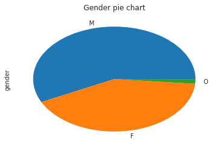

```python
profile.gender.value_counts().plot.pie(title="Gender pie chart")
```

```python
profile.info()
```

```
<class 'pandas.core.frame.DataFrame'>
RangeIndex: 17000 entries, 0 to 16999
Data columns (total 5 columns):
age                 17000 non-null int64
became_member_on    17000 non-null int64
gender              14825 non-null object
id                  17000 non-null object
income              14825 non-null float64
dtypes: float64(1), int64(2), object(2)
memory usage: 664.1+ KB
```

```python
profile.describe()
```

|  | age | became_member_on | income |
| --- | --- | --- | --- |
| count | 17000.000000 | 1.700000e+04 | 14825.000000 |
| mean | 62.531412 | 2.016703e+07 | 65404.991568 |
| std | 26.738580 | 1.167750e+04 | 21598.299410 |
| min | 18.000000 | 2.013073e+07 | 30000.000000 |
| 25% | 45.000000 | 2.016053e+07 | 49000.000000 |
| 50% | 58.000000 | 2.017080e+07 | 64000.000000 |
| 75% | 73.000000 | 2.017123e+07 | 80000.000000 |
| max | 118.000000 | 2.018073e+07 | 120000.000000 |

#### Insights from profile.json

- The dataset has 5 columns and 17,000 rows.
- The dataset has 2175 missing values on: 'gender', 'income' column. Corresponding age column of those records are set to default 118. These missing values need to be cleaned.
- There are three 'gender' categories- M (8484), F (6129) and O (212). O could be associated with missing value records.
- Income ranges from 30000 and 120000 where maximum customers have income ranges between 50000-75000.
- Most customers are between 45-70 age.

### 3. transcrpt.json

```python
transcript.head()
```

|  | event | person | time | value |
| --- | --- | --- | --- | --- |
| 0 | offer received | 78afa995795e4d85b5d9ceeca43f5fef | 0 | {'offer id': '9b98b8c7a33c4b65b9aebfe6a799e6d9'} |
| 1 | offer received | a03223e636434f42ac4c3df47e8bac43 | 0 | {'offer id': '0b1e1539f2cc45b7b9fa7c272da2e1d7'} |
| 2 | offer received | e2127556f4f64592b11af22de27a7932 | 0 | {'offer id': '2906b810c7d4411798c6938adc9daaa5'} |
| 3 | offer received | 8ec6ce2a7e7949b1bf142def7d0e0586 | 0 | {'offer id': 'fafdcd668e3743c1bb461111dcafc2a4'} |
| 4 | offer received | 68617ca6246f4fbc85e91a2a49552598 | 0 | {'offer id': '4d5c57ea9a6940dd891ad53e9dbe8da0'} |

```python
transcript.event.unique()
```

```
array(['offer received', 'offer viewed', 'transaction', 'offer completed'], dtype=object)
```

```python
transcript['event'].value_counts()
```

```
transaction        138953
offer received      76277
offer viewed        57725
offer completed     33579
Name: event, dtype: int64
```

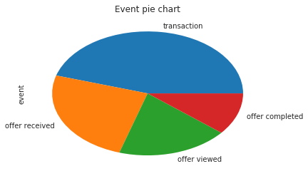

```python
transcript['event'].value_counts().plot.pie(title="Event pie chart")
```

```python
transcript.isna().sum()
```

```
event     0
person    0
time      0
value     0
dtype: int64
```

```python
transcript.info()
```

```
<class 'pandas.core.frame.DataFrame'>
RangeIndex: 306534 entries, 0 to 306533
Data columns (total 4 columns):
event     306534 non-null object
person    306534 non-null object
time      306534 non-null int64
value     306534 non-null object
dtypes: int64(1), object(3)
memory usage: 9.4+ MB
```

```python
transcript.describe()
```

|  | time |
| --- | --- |
| count | 306534.000000 |
| mean | 366.382940 |
| std | 200.326314 |
| min | 0.000000 |
| 25% | 186.000000 |
| 50% | 408.000000 |
| 75% | 528.000000 |
| max | 714.000000 |

#### Insights from transaction.json

- The dataset has 4 columns and 306,534 rows.
- The dataset has no missing values.
- The 'value' column is a dictionary and needs to be proccessed.
- All events in this dataset are: 'transaction', 'offer received', 'offer viewed' and 'offer completed'.
- transaction event can be used to calculate money_spent

# Data preprocessing

### 1. portfolio.json

```python
# renaming portfolio 'id' column to offer_id.
portfolio.rename(columns={'id':'offer_id'}, inplace=True)
```

```python
# renaming portfolio 'duration' column to 'duration_hour'.
# changing portfolio 'duration' column unit from days to hours
# beacuse transcript 'time' column is in hours
portfolio.rename(columns={'duration':'duration_hour'}, inplace=True)
portfolio['duration_hour'] = portfolio['duration_hour']*24
```

```python
portfolio['channels']
```

```
0         [email, mobile, social]
1    [web, email, mobile, social]
2            [web, email, mobile]
3            [web, email, mobile]
4                    [web, email]
5    [web, email, mobile, social]
6    [web, email, mobile, social]
7         [email, mobile, social]
8    [web, email, mobile, social]
9            [web, email, mobile]
Name: channels, dtype: object
```

```python
# one_hot_encoding applied to portfolio 'channels' column
portfolio['web'] = portfolio['channels'].apply(lambda x: 1 if 'web' in x else 0)
portfolio['email'] = portfolio['channels'].apply(lambda x: 1 if 'email' in x else 0)
portfolio['mobile'] = portfolio['channels'].apply(lambda x: 1 if 'mobile' in x else 0)
portfolio['social'] = portfolio['channels'].apply(lambda x: 1 if 'social' in x else 0)
```

```python
# one_hot_encoding applied to portfolio 'offer_type' column
portfolio['bogo_offer'] = portfolio['offer_type'].apply(lambda x: 1 if x == 'bogo' else 0)
portfolio['informational_offer'] = portfolio['offer_type'].apply(lambda x: 1 if x == 'informational' else 0)
portfolio['discount_offer'] = portfolio['offer_type'].apply(lambda x: 1 if x == 'discount' else 0)
```

```python
# dropping portfolio 'channels' column
portfolio.drop('channels', axis=1, inplace=True)
```

```python
# dropping portfolio 'offer_type' column
portfolio.drop('offer_type', axis=1, inplace=True)
```

```python
portfolio.head()
```

|  | difficulty | duration_hour | offer_id | reward | web | email | mobile | social | bogo_offer | informational_offer | discount_offer |
| --- | --- | --- | --- | --- | --- | --- | --- | --- | --- | --- | --- |
| 0 | 10 | 168 | ae264e3637204a6fb9bb56bc8210ddfd | 10 | 0 | 1 | 1 | 1 | 1 | 0 | 0 |
| 1 | 10 | 120 | 4d5c57ea9a6940dd891ad53e9dbe8da0 | 10 | 1 | 1 | 1 | 1 | 1 | 0 | 0 |
| 2 | 0 | 96 | 3f207df678b143eea3cee63160fa8bed | 0 | 1 | 1 | 1 | 0 | 0 | 1 | 0 |
| 3 | 5 | 168 | 9b98b8c7a33c4b65b9aebfe6a799e6d9 | 5 | 1 | 1 | 1 | 0 | 1 | 0 | 0 |
| 4 | 20 | 240 | 0b1e1539f2cc45b7b9fa7c272da2e1d7 | 5 | 1 | 1 | 0 | 0 | 0 | 0 | 1 |

### 2. profile.json

```python
# renaming profile 'id' column to customer_id.
profile.rename(columns={'id':'customer_id'}, inplace=True)
```

```python
# replacing the age = 118 the default value by NaN value
profile['age'] = profile['age'].apply(lambda x: np.nan if x == 118 else x)
```

```python
# number of days, a user is a memeber of starbucks
profile['became_member_on'] = pd.to_datetime(profile['became_member_on'], format = '%Y%m%d')
profile['membership_days'] = (datetime.datetime.today().date() - profile['became_member_on'].dt.date).dt.days
```

```python
profile.membership_days.describe()
```

```
count    17000.000000
mean      1339.449882
std        411.223904
min        822.000000
25%       1030.000000
50%       1180.000000
75%       1613.000000
max       2645.000000
Name: membership_days, dtype: float64
```

```python
# drop all missing values
profile.dropna(inplace=True)
```

```python
profile.isna().sum()
```

```
age                 0
became_member_on    0
gender              0
customer_id         0
income              0
membership_days     0
dtype: int64
```

```python
# creating 'age_group' to classify customers' age range
profile['age_group'] = pd.cut(profile['age'], bins=[17, 30, 45, 60, 105], labels=['young_adult', 'middle_aged', 'old', 'elderly'])
```

```python
# creating 'income_range' to classify customers' income range
profile['income_range'] = pd.cut(profile['income'], bins=[29999, 50000, 90000, 120001], labels=['average', 'above_average', 'high'])
```

```python
# creating 'member_category' to classify customers' memebership duration
profile['member_category'] = pd.cut(profile['membership_days'], bins=[800, 1600, 2700],labels=['regular', 'long_term'])
```

```python
profile.head()
```

|  | age | became_member_on | gender | customer_id | income | membership_days | age_group | income_range | member_category |
| --- | --- | --- | --- | --- | --- | --- | --- | --- | --- |
| 1 | 55.0 | 2017-07-15 | F | 0610b486422d4921ae7d2bf64640c50b | 112000.0 | 1198 | old | high | regular |
| 3 | 75.0 | 2017-05-09 | F | 78afa995795e4d85b5d9ceeca43f5fef | 100000.0 | 1265 | elderly | high | regular |
| 5 | 68.0 | 2018-04-26 | M | e2127556f4f64592b11af22de27a7932 | 70000.0 | 913 | elderly | above_average | regular |
| 8 | 65.0 | 2018-02-09 | M | 389bc3fa690240e798340f5a15918d5c | 53000.0 | 989 | elderly | above_average | regular |
| 12 | 58.0 | 2017-11-11 | M | 2eeac8d8feae4a8cad5a6af0499a211d | 51000.0 | 1079 | old | above_average | regular |

### 3. transcript.json

```python
# renaming profile 'id' column to customer_id.
transcript.rename(columns={'person':'customer_id'}, inplace=True)
```

```python
#creating 'offer_id' and 'reward' columns
transcript['offer_id'] = ''
transcript['reward'] = 0
transcript['amount'] = 0.0
```

```python
# Iterating over transcript dataset and checking 'value' column
# then updatingin the columns created above
for idx, row in transcript.iterrows():
    for val in row['value']:
        if val == 'offer_id' or val == 'offer id':
            #print(row)
            transcript.at[idx, 'offer_id'] = row['value'][val]
        if val == 'reward':
            #print(row)
            transcript.at[idx, 'reward'] = row['value'][val]
        if val == 'amount':
            #print(row)
            transcript.at[idx, 'amount'] = row['value'][val]
```

```python
# creating transaction_df consisting of the transaction events
transaction_df = transcript[transcript['event'] == 'transaction']
```

```python
# dropping 'event', 'value', 'offer_id', 'reward' columns
transaction_df = transaction_df.drop(columns = ['event', 'value', 'offer_id', 'reward'], axis=1)
```

```python
transaction_df.head()
```

|  | customer_id | time | amount |
| --- | --- | --- | --- |
| 12654 | 02c083884c7d45b39cc68e1314fec56c | 0 | 0.83 |
| 12657 | 9fa9ae8f57894cc9a3b8a9bbe0fc1b2f | 0 | 34.56 |
| 12659 | 54890f68699049c2a04d415abc25e717 | 0 | 13.23 |
| 12670 | b2f1cd155b864803ad8334cdf13c4bd2 | 0 | 19.51 |
| 12671 | fe97aa22dd3e48c8b143116a8403dd52 | 0 | 18.97 |

```python
# removing transaction events from transcript
transcript = transcript[transcript['event'] != 'transaction']
```

```python
transcript.event.unique()
```

```
array(['offer received', 'offer viewed', 'offer completed'], dtype=object)
```

```python
# one_hot_encoding applied to transcript 'event' column
transcript['offer received'] = transcript['event'].apply(lambda x: 1 if x == 'offer received' else 0)
transcript['offer viewed'] = transcript['event'].apply(lambda x: 1 if x == 'offer viewed' else 0)
transcript['offer completed'] = transcript['event'].apply(lambda x: 1 if x == 'offer completed' else 0)
```

```python
# creating offer_df from transcript columns
offer_df = transcript[['customer_id', 'offer_id', 'time', 'offer completed', 'offer received', 'offer viewed']]
```

```python
offer_df.tail()
```

|  | customer_id | offer_id | time | offer completed | offer received | offer viewed |
| --- | --- | --- | --- | --- | --- | --- |
| 306497 | a6f84f4e976f44508c358cc9aba6d2b3 | 2298d6c36e964ae4a3e7e9706d1fb8c2 | 714 | 1 | 0 | 0 |
| 306506 | b895c57e8cd047a8872ce02aa54759d6 | fafdcd668e3743c1bb461111dcafc2a4 | 714 | 1 | 0 | 0 |
| 306507 | 8dda575c2a1d44b9ac8e8b07b93d1f8e | 0b1e1539f2cc45b7b9fa7c272da2e1d7 | 714 | 0 | 0 | 1 |
| 306509 | 8431c16f8e1d440880db371a68f82dd0 | fafdcd668e3743c1bb461111dcafc2a4 | 714 | 1 | 0 | 0 |
| 306527 | 24f56b5e1849462093931b164eb803b5 | fafdcd668e3743c1bb461111dcafc2a4 | 714 | 1 | 0 | 0 |

# Creating final cleaned merged dataframe

```python
def clean_data(portfolio, profile, offer_df, transaction_df):
    '''
    Combine portfolio, profile, offer_df, and transaction_df

    Args:
        portfolio: Clean DataFrame of portfolio
        profile: Clean DataFrame of profile
        offer_df: Clean DataFrame of offer
        transaction_df: Clean DataFrame of transaction
    Returns:
        clean_data: DataFrame containing merged information from
                    all of the data input
    '''
    clean_data = []
    customer_list = profile['customer_id'].unique().tolist()
    for customer_id in customer_list:
        index_customer = profile[profile['customer_id'] == customer_id]
        offer_filtered = offer_df[offer_df['customer_id'] == customer_id]
        transaction_id = transaction_df[transaction_df['customer_id'] == customer_id]

        offer_complete = offer_filtered[offer_filtered['offer completed'] == 1]
        offer_view = offer_filtered[offer_filtered['offer viewed'] == 1]
        offer_receive = offer_filtered[offer_filtered['offer received'] == 1]

        # Loop through customers who obtained offers
        for index in range(len(offer_receive)):
            offer_id = offer_receive.iloc[index]['offer_id']
            offer_info = portfolio[portfolio['offer_id'] == offer_id]
            duration = offer_info['duration_hour'].values[0]
            portfolio = offer_info[['duration_hour', 'reward', 'difficulty',
                                    'bogo_offer', 'discount_offer', 'informational_offer',
                                    'email', 'mobile', 'social',
                                    'web']].values[0]

            customer = index_customer[['gender', 'age', 'age_group', 'income', 'income_range',
                                       'membership_days', 'member_category', 'became_member_on']].values[0]

            offer_start = offer_receive.iloc[index]['time']
            offer_end = offer_start + duration

            # np.logical_and is used instead of and to avoid ambiguous truth value
            transaction_filter = np.logical_and(transaction_id['time'] >= offer_start,
                                                transaction_id['time'] <= offer_end)
            completed_filter =  np.logical_and(offer_complete['time'] >= offer_start,
                                               offer_complete['time'] <= offer_end)
            viewed_filter = np.logical_and(offer_view['time'] >= offer_start,
                                           offer_view['time'] <= offer_end)

            offer_finished = (completed_filter.sum() > 0) and (viewed_filter.sum() > 0)
            # assign 1 if offer is fulfilled, 0 if not
            period_transaction = transaction_id[transaction_filter]['amount'].sum()
            # amount of transaction during the offer

            data_entry_1 = [offer_id, customer_id, int(offer_finished), period_transaction]
            data_entry_2 = list(portfolio)
            data_entry_3 = list(customer)

            data = data_entry_1 + data_entry_2 + data_entry_3

            clean_data.append(data)

    column_names = ['offer_id', 'customer_id', 'offer_completed', 'money_spent',# data entry 1
                    'duration_hour', 'reward', 'difficulty', 'bogo_offer',      # data entry 2
                    'discount_offer', 'informational_offer', 'email', 'mobile', # data entry 2
                    'social', 'web',                                            # data entry 2
                    'gender', 'age', 'age_group', 'income', 'income_range', 'membership_days',
                    'member_category', 'became_member_on'] # data entry 3

    clean_data = pd.DataFrame(data = clean_data, columns = column_names)
    clean_data['became_member_on'] = clean_data['became_member_on'].dt.year

    return clean_data
```

```python
# merging data
merged_data = clean_data(portfolio, profile, offer_df, transaction_df)

# saving data to csv
merged_data.to_csv('data/merged_final_data.csv', index = False)
```

```python
# reading from csv
merged_data = pd.read_csv('data/merged_final_data.csv')
```

```python
merged_data.tail()
```

|  | offer_id | customer_id | offer_completed | money_spent | duration_hour | reward | difficulty | bogo_offer | discount_offer | informational_offer | ... | social | web | gender | age | age_group | income | income_range | membership_days | member_category | became_member_on |
| --- | --- | --- | --- | --- | --- | --- | --- | --- | --- | --- | --- | --- | --- | --- | --- | --- | --- | --- | --- | --- | --- |
| 66496 | ae264e3637204a6fb9bb56bc8210ddfd | 9dc1421481194dcd9400aec7c9ae6366 | 1 | 58.50 | 168 | 10 | 10 | 1 | 0 | 0 | ... | 1 | 0 | F | 83.0 | elderly | 50000.0 | average | 1693 | long_term | 2016 |
| 66497 | 2298d6c36e964ae4a3e7e9706d1fb8c2 | e4052622e5ba45a8b96b59aba68cf068 | 1 | 68.27 | 168 | 3 | 7 | 0 | 1 | 0 | ... | 1 | 1 | F | 62.0 | elderly | 82000.0 | above_average | 1191 | regular | 2017 |
| 66498 | 3f207df678b143eea3cee63160fa8bed | e4052622e5ba45a8b96b59aba68cf068 | 0 | 0.00 | 96 | 0 | 0 | 0 | 0 | 1 | ... | 0 | 1 | F | 62.0 | elderly | 82000.0 | above_average | 1191 | regular | 2017 |
| 66499 | f19421c1d4aa40978ebb69ca19b0e20d | e4052622e5ba45a8b96b59aba68cf068 | 0 | 50.04 | 120 | 5 | 5 | 1 | 0 | 0 | ... | 1 | 1 | F | 62.0 | elderly | 82000.0 | above_average | 1191 | regular | 2017 |
| 66500 | 3f207df678b143eea3cee63160fa8bed | e4052622e5ba45a8b96b59aba68cf068 | 0 | 0.00 | 96 | 0 | 0 | 0 | 0 | 1 | ... | 0 | 1 | F | 62.0 | elderly | 82000.0 | above_average | 1191 | regular | 2017 |

5 rows × 22 columns

# Exploratory Visualization

## Offer Completion by age_group

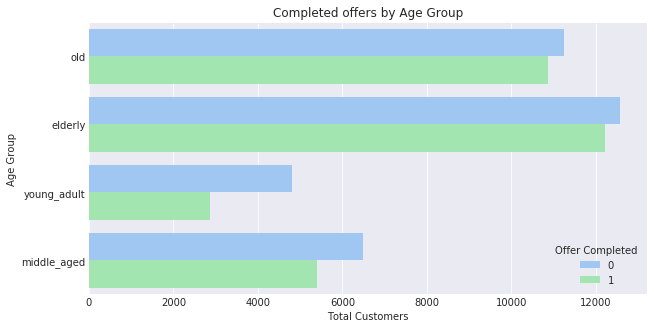

```python
plt.figure(figsize=(10, 5))
sns.countplot(y="age_group", hue="offer_completed", palette = "pastel", data=merged_data)
plt.title('Completed offers by Age Group')
plt.xlabel('Total Customers')
plt.ylabel('Age Group')
plt.legend(title='Offer Completed')
plt.show()
```

- 45 and above aged people tend to complete more offers

## Offer Completion by Gender

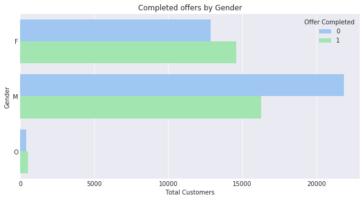

```python
plt.figure(figsize=(10, 5))
sns.countplot(y="gender", hue="offer_completed", palette = "pastel", data=merged_data)
plt.title('Completed offers by Gender')
plt.xlabel('Total Customers')
plt.ylabel('Gender')
plt.legend(title='Offer Completed')
plt.show()
```

## Offer Completion by Income range

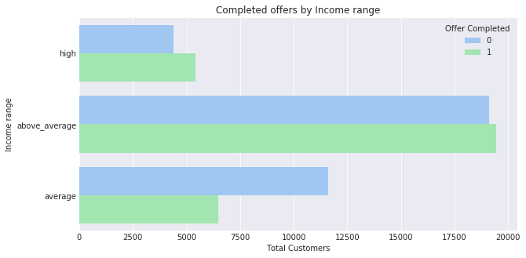

```python
plt.figure(figsize=(10, 5))
sns.countplot(y="income_range", hue="offer_completed", palette = "pastel", data=merged_data)
plt.title('Completed offers by Income range')
plt.xlabel('Total Customers')
plt.ylabel('Income range')
plt.legend(title='Offer Completed')
plt.show()
```

- people earning more than 50k tend to accept more offers

## Offer completed by Membership year

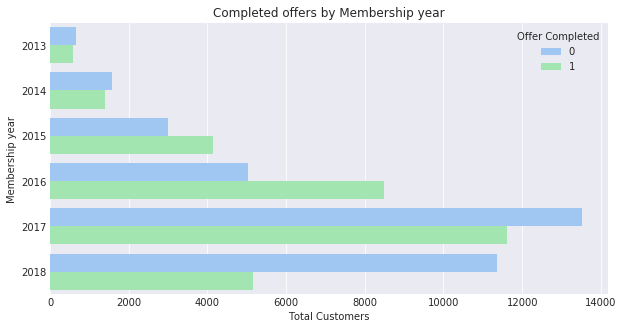

```python
plt.figure(figsize=(10, 5))
sns.countplot(y="became_member_on", hue="offer_completed", palette = "pastel", data=merged_data)
plt.title('Completed offers by Membership year')
plt.xlabel('Total Customers')
plt.ylabel('Membership year')
plt.legend(title='Offer Completed')
plt.show()
```

# Feature Engineering

## Encoding categorical columns with numerical values

```python
# encoding applied to'gender' column
gender_map = {'O':0, 'M':1, 'F':2}
merged_data['gender'] = merged_data['gender'].map(gender_map)

# encoding applied to 'age_group' column
age_group_map = {'young_adult':0, 'middle_aged':1, 'old':2, 'elderly':3}
merged_data['age_group'] = merged_data['age_group'].map(age_group_map)

# encoding applied to 'income_range' column
income_range_map = {'average':0, 'above_average':1, 'high':2}
merged_data['income_range'] = merged_data['income_range'].map(income_range_map)

# encoding applied to 'member_category' column
member_category = {'regular':1, 'long_term':2}
merged_data['member_category'] = merged_data['member_category'].map(member_category)

# encoding 'offer_id' strings with numerical values
offer_id_map = {'ae264e3637204a6fb9bb56bc8210ddfd':0,
               '4d5c57ea9a6940dd891ad53e9dbe8da0':1,
               '3f207df678b143eea3cee63160fa8bed':2,
               '9b98b8c7a33c4b65b9aebfe6a799e6d9':3,
               '0b1e1539f2cc45b7b9fa7c272da2e1d7':4,
               '2298d6c36e964ae4a3e7e9706d1fb8c2':5,
               'fafdcd668e3743c1bb461111dcafc2a4':6,
               '5a8bc65990b245e5a138643cd4eb9837':7,
               'f19421c1d4aa40978ebb69ca19b0e20d':8,
               '2906b810c7d4411798c6938adc9daaa5':9}
merged_data['offer_id'] = merged_data['offer_id'].map(offer_id_map)
```

## Normalizing features

```python
# Initializing a scaler to apply on the features
scaler = MinMaxScaler() # default=(0, 1)
numerical = ['money_spent', 'duration_hour', 'reward',
             'difficulty', 'income', 'membership_days']
merged_data[numerical] = scaler.fit_transform(merged_data[numerical])
```

```python
# correlation among columns
merged_data.corr()
```

|  | offer_id | offer_completed | money_spent | duration_hour | reward | difficulty | bogo_offer | discount_offer | informational_offer | email | ... | social | web | gender | age | age_group | income | income_range | membership_days | member_category | became_member_on |
| --- | --- | --- | --- | --- | --- | --- | --- | --- | --- | --- | --- | --- | --- | --- | --- | --- | --- | --- | --- | --- | --- |
| offer_id | 1.000000 | 0.037373 | 0.004945 | 0.007746 | -0.604637 | -0.103124 | -0.428066 | 0.427215 | 0.000625 | NaN | ... | 0.000294 | 0.175232 | -0.000567 | 0.001160 | 0.000848 | 0.001494 | 0.001648 | -0.005794 | -0.004389 | 0.004775 |
| offer_completed | 0.037373 | 1.000000 | 0.376093 | 0.294742 | 0.191328 | 0.229377 | 0.112317 | 0.216109 | -0.402291 | NaN | ... | 0.160234 | 0.166774 | 0.090676 | 0.066232 | 0.067282 | 0.143236 | 0.134975 | 0.160748 | 0.119713 | -0.157677 |
| money_spent | 0.004945 | 0.376093 | 1.000000 | 0.160693 | 0.042710 | 0.116729 | -0.012380 | 0.120023 | -0.131900 | NaN | ... | 0.039172 | 0.048939 | 0.086335 | 0.060088 | 0.060305 | 0.181374 | 0.160419 | 0.108234 | 0.080283 | -0.107903 |
| duration_hour | 0.007746 | 0.294742 | 0.160693 | 1.000000 | 0.161964 | 0.809257 | -0.184856 | 0.741376 | -0.682049 | NaN | ... | -0.185837 | 0.340997 | -0.004168 | -0.003150 | -0.001169 | -0.002406 | -0.006337 | 0.001714 | 0.006530 | -0.000641 |
| reward | -0.604637 | 0.191328 | 0.042710 | 0.161964 | 1.000000 | 0.465176 | 0.791978 | -0.287104 | -0.617818 | NaN | ... | 0.286961 | -0.120241 | 0.001388 | -0.004319 | -0.003136 | 0.001971 | -0.000190 | 0.003557 | 0.002148 | -0.002509 |
| difficulty | -0.103124 | 0.229377 | 0.116729 | 0.809257 | 0.465176 | 1.000000 | -0.031252 | 0.598690 | -0.695277 | NaN | ... | -0.156460 | 0.243572 | -0.000614 | -0.004088 | -0.003406 | -0.000858 | -0.005173 | 0.001820 | 0.003982 | -0.000513 |
| bogo_offer | -0.428066 | 0.112317 | -0.012380 | -0.184856 | 0.791978 | -0.031252 | 1.000000 | -0.666670 | -0.407434 | NaN | ... | 0.248637 | -0.104735 | 0.001800 | -0.001719 | -0.000724 | 0.001996 | 0.001154 | 0.003498 | 0.001448 | -0.003346 |
| discount_offer | 0.427215 | 0.216109 | 0.120023 | 0.741376 | -0.287104 | 0.598690 | -0.666670 | 1.000000 | -0.409058 | NaN | ... | -0.165987 | 0.409558 | -0.003880 | -0.002753 | -0.002075 | -0.001996 | -0.003680 | -0.003492 | 0.000116 | 0.003954 |
| informational_offer | 0.000625 | -0.402291 | -0.131900 | -0.682049 | -0.617818 | -0.695277 | -0.407434 | -0.409058 | 1.000000 | NaN | ... | -0.101023 | -0.373582 | 0.002550 | 0.005478 | 0.003429 | 0.000003 | 0.003096 | -0.000004 | -0.001915 | -0.000749 |
| email | NaN | NaN | NaN | NaN | NaN | NaN | NaN | NaN | NaN | NaN | ... | NaN | NaN | NaN | NaN | NaN | NaN | NaN | NaN | NaN | NaN |
| mobile | 0.057732 | 0.009421 | -0.035799 | -0.531442 | -0.079089 | -0.742892 | 0.273344 | -0.410015 | 0.167720 | NaN | ... | 0.409566 | -0.167925 | -0.001708 | -0.000239 | 0.000883 | 0.002979 | 0.005947 | -0.001643 | -0.001825 | 0.000363 |
| social | 0.000294 | 0.160234 | 0.039172 | -0.185837 | 0.286961 | -0.156460 | 0.248637 | -0.165987 | -0.101023 | NaN | ... | 1.000000 | -0.410007 | -0.000335 | -0.000272 | 0.001456 | 0.004771 | 0.006363 | -0.003820 | -0.005352 | 0.004258 |
| web | 0.175232 | 0.166774 | 0.048939 | 0.340997 | -0.120241 | 0.243572 | -0.104735 | 0.409558 | -0.373582 | NaN | ... | -0.410007 | 1.000000 | -0.002085 | -0.000266 | -0.001484 | -0.004473 | -0.004704 | -0.001900 | -0.001360 | 0.001381 |
| gender | -0.000567 | 0.090676 | 0.086335 | -0.004168 | 0.001388 | -0.000614 | 0.001800 | -0.003880 | 0.002550 | NaN | ... | -0.000335 | -0.002085 | 1.000000 | 0.141769 | 0.130777 | 0.219368 | 0.189991 | -0.013822 | -0.020819 | 0.005159 |
| age | 0.001160 | 0.066232 | 0.060088 | -0.003150 | -0.004319 | -0.004088 | -0.001719 | -0.002753 | 0.005478 | NaN | ... | -0.000272 | -0.000266 | 0.141769 | 1.000000 | 0.931767 | 0.305156 | 0.267936 | 0.008904 | 0.008723 | -0.010001 |
| age_group | 0.000848 | 0.067282 | 0.060305 | -0.001169 | -0.003136 | -0.003406 | -0.000724 | -0.002075 | 0.003429 | NaN | ... | 0.001456 | -0.001484 | 0.130777 | 0.931767 | 1.000000 | 0.310773 | 0.273883 | 0.011916 | 0.010588 | -0.013427 |
| income | 0.001494 | 0.143236 | 0.181374 | -0.002406 | 0.001971 | -0.000858 | 0.001996 | -0.001996 | 0.000003 | NaN | ... | 0.004771 | -0.004473 | 0.219368 | 0.305156 | 0.310773 | 1.000000 | 0.896243 | 0.022914 | 0.016378 | -0.026660 |
| income_range | 0.001648 | 0.134975 | 0.160419 | -0.006337 | -0.000190 | -0.005173 | 0.001154 | -0.003680 | 0.003096 | NaN | ... | 0.006363 | -0.004704 | 0.189991 | 0.267936 | 0.273883 | 0.896243 | 1.000000 | 0.028430 | 0.018363 | -0.031280 |
| membership_days | -0.005794 | 0.160748 | 0.108234 | 0.001714 | 0.003557 | 0.001820 | 0.003498 | -0.003492 | -0.000004 | NaN | ... | -0.003820 | -0.001900 | -0.013822 | 0.008904 | 0.011916 | 0.022914 | 0.028430 | 1.000000 | 0.837662 | -0.969884 |
| member_category | -0.004389 | 0.119713 | 0.080283 | 0.006530 | 0.002148 | 0.003982 | 0.001448 | 0.000116 | -0.001915 | NaN | ... | -0.005352 | -0.001360 | -0.020819 | 0.008723 | 0.010588 | 0.016378 | 0.018363 | 0.837662 | 1.000000 | -0.787575 |
| became_member_on | 0.004775 | -0.157677 | -0.107903 | -0.000641 | -0.002509 | -0.000513 | -0.003346 | 0.003954 | -0.000749 | NaN | ... | 0.004258 | 0.001381 | 0.005159 | -0.010001 | -0.013427 | -0.026660 | -0.031280 | -0.969884 | -0.787575 | 1.000000 |

21 rows × 21 columns

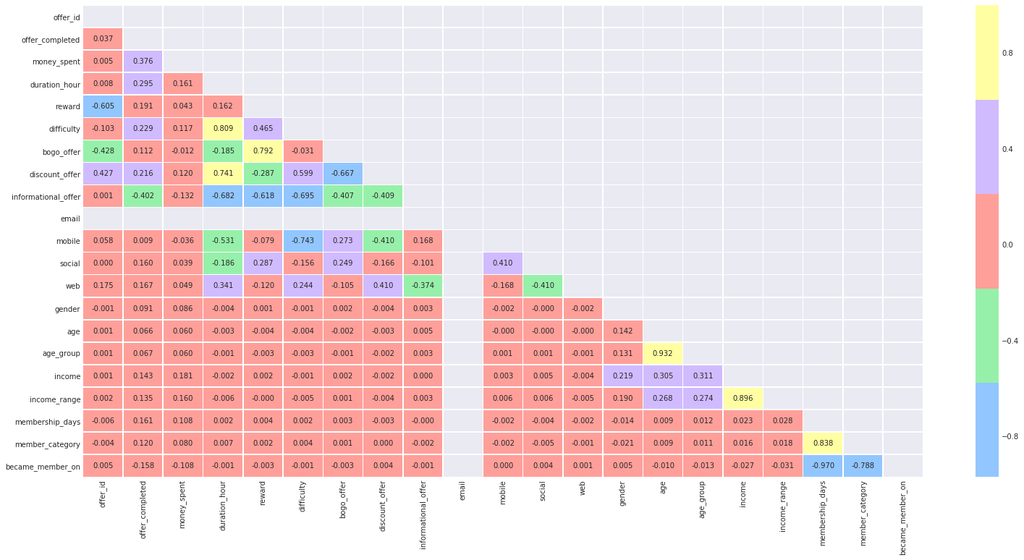

```python
# correlation heatmap plotting to select variables for modeling
corr = merged_data.corr()
mask = np.triu(corr)
cmap = sns.color_palette("pastel", 5)

with sns.axes_style('dark'):
    f, ax = plt.subplots(figsize = (26, 12))
    ax = sns.heatmap(corr, mask = mask, cmap = cmap, annot = True, fmt = '.3f', linewidths=.5)
```

# Data modeling

```python
from sklearn.model_selection import train_test_split, GridSearchCV
from sklearn.svm import SVC
from sklearn.ensemble import GradientBoostingClassifier
from sklearn.linear_model import LogisticRegression
from sklearn.ensemble import RandomForestClassifier
from sklearn.metrics import f1_score
from sklearn.metrics import classification_report
from sklearn.metrics import confusion_matrix
from sklearn import metrics
from sklearn.metrics import roc_auc_score
from sklearn.model_selection import cross_val_score, learning_curve
```

### Logistic Regression (Benchmark)

```python
# selecting features
X = merged_data[['money_spent', 'duration_hour', 'reward', 'difficulty', 'bogo_offer',
              'discount_offer', 'informational_offer', 'social', 'web',
              'member_category', 'became_member_on', 'gender', 'age_group', 'income_range']]
# offer completed will be our dependent variable
y = merged_data['offer_completed']
```

```python
# splitting data into train and test sets
X_train, X_test, y_train, y_test = train_test_split(X, y, stratify=y, test_size=0.30, random_state=42)
```

### Loginstic regression with hyperparameter tuning

```python
log_model = LogisticRegression()

param_grid = {'penalty': ['l1','l2'],
              'C': [0.001,0.01,0.1,1,10,100,1000]}

log_grid = GridSearchCV(log_model, param_grid, verbose=3)
# fiiting to model
log_grid.fit(X_train, y_train)
```

```
Fitting 3 folds for each of 14 candidates, totalling 42 fits
[CV] C=0.001, penalty=l1 .............................................
[CV] .... C=0.001, penalty=l1, score=0.6456373243974739, total=   0.1s
[CV] C=0.001, penalty=l1 .............................................
[CV] .... C=0.001, penalty=l1, score=0.6410801753029132, total=   0.1s
[CV] C=0.001, penalty=l1 .............................................
```

```
[Parallel(n_jobs=1)]: Done   1 out of   1 | elapsed:    0.1s remaining:    0.0s
[Parallel(n_jobs=1)]: Done   2 out of   2 | elapsed:    0.2s remaining:    0.0s
```

[output not shown]

[output cut: 24 more lines]

```
[CV] ....... C=100, penalty=l2, score=0.879865944831142, total=   0.8s
[CV] C=100, penalty=l2 ...............................................
[CV] ...... C=100, penalty=l2, score=0.8743877287960815, total=   1.0s
[CV] C=1000, penalty=l1 ..............................................
[CV] ..... C=1000, penalty=l1, score=0.8798169867250935, total=  17.9s
[CV] C=1000, penalty=l1 ..............................................
[CV] ..... C=1000, penalty=l1, score=0.8801881928332045, total=   0.3s
[CV] C=1000, penalty=l1 ..............................................
[CV] ..... C=1000, penalty=l1, score=0.8767723640113432, total=   0.3s
[CV] C=1000, penalty=l2 ..............................................
[CV] ..... C=1000, penalty=l2, score=0.8735017399149375, total=   0.8s
[CV] C=1000, penalty=l2 ..............................................
[CV] ..... C=1000, penalty=l2, score=0.8800592936323794, total=   0.9s
[CV] C=1000, penalty=l2 ..............................................
[CV] ..... C=1000, penalty=l2, score=0.8752255736014437, total=   0.8s
```

```
[Parallel(n_jobs=1)]: Done  42 out of  42 | elapsed:  1.7min finished
```

```
GridSearchCV(cv=None, error_score='raise',
       estimator=LogisticRegression(C=1.0, class_weight=None, dual=False, fit_intercept=True,
          intercept_scaling=1, max_iter=100, multi_class='ovr', n_jobs=1,
          penalty='l2', random_state=None, solver='liblinear', tol=0.0001,
          verbose=0, warm_start=False),
       fit_params=None, iid=True, n_jobs=1,
       param_grid={'penalty': ['l1', 'l2'], 'C': [0.001, 0.01, 0.1, 1, 10, 100, 1000]},
       pre_dispatch='2*n_jobs', refit=True, return_train_score='warn',
       scoring=None, verbose=3)
```

```python
y_pred = log_grid.predict(X_test)
log_cr = classification_report(y_test, y_pred)
log_cm = confusion_matrix(y_test, y_pred)
print(log_cr)
```

```
             precision    recall  f1-score   support

          0       0.86      0.92      0.89     10541
          1       0.90      0.83      0.87      9410

avg / total       0.88      0.88      0.88     19951
```

```
Text(0.5,18.5,'Predicted label')
```

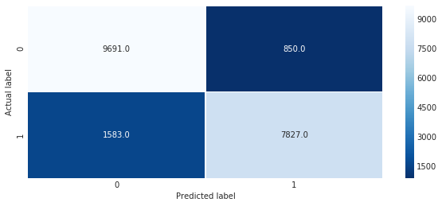

```python
plt.figure(figsize = (10, 4))
sns.heatmap(log_cm, annot=True, fmt=".1f", linewidths=.3, cmap = 'Blues_r')
plt.ylabel('Actual label')
plt.xlabel('Predicted label')
```

### Random Forest Classifier with hyperparameter tuning

```python
#random_forest = RandomForestClassifier(max_depth=3, random_state=0)
random_forest = RandomForestClassifier()
param_grid = {'max_depth': [3, 5],
             'min_samples_leaf': [2, 3],
             'n_estimators': [100, 1000, 2000]}
rf_grid = GridSearchCV(random_forest, param_grid, verbose = 3)
rf_grid.fit(X_train, y_train)
```

```
Fitting 3 folds for each of 12 candidates, totalling 36 fits
[CV] max_depth=3, min_samples_leaf=2, n_estimators=100 ...............
[CV]  max_depth=3, min_samples_leaf=2, n_estimators=100, score=0.899342698801392, total=   1.1s
[CV] max_depth=3, min_samples_leaf=2, n_estimators=100 ...............
```

```
[Parallel(n_jobs=1)]: Done   1 out of   1 | elapsed:    1.3s remaining:    0.0s
```

```
[CV]  max_depth=3, min_samples_leaf=2, n_estimators=100, score=0.8964294921371487, total=   1.1s
[CV] max_depth=3, min_samples_leaf=2, n_estimators=100 ...............
```

```
[Parallel(n_jobs=1)]: Done   2 out of   2 | elapsed:    2.6s remaining:    0.0s
```

[output not shown]

[output cut: 12 more lines]

```
[CV]  max_depth=5, min_samples_leaf=3, n_estimators=100, score=0.8988785769528229, total=   1.5s
[CV] max_depth=5, min_samples_leaf=3, n_estimators=100 ...............
[CV]  max_depth=5, min_samples_leaf=3, n_estimators=100, score=0.8992008249548853, total=   1.6s
[CV] max_depth=5, min_samples_leaf=3, n_estimators=1000 ..............
[CV]  max_depth=5, min_samples_leaf=3, n_estimators=1000, score=0.9012759376208275, total=  15.6s
[CV] max_depth=5, min_samples_leaf=3, n_estimators=1000 ..............
[CV]  max_depth=5, min_samples_leaf=3, n_estimators=1000, score=0.8985563289507605, total=  15.6s
[CV] max_depth=5, min_samples_leaf=3, n_estimators=1000 ..............
[CV]  max_depth=5, min_samples_leaf=3, n_estimators=1000, score=0.8977829337458108, total=  15.6s
[CV] max_depth=5, min_samples_leaf=3, n_estimators=2000 ..............
[CV]  max_depth=5, min_samples_leaf=3, n_estimators=2000, score=0.9010826137388839, total=  31.7s
[CV] max_depth=5, min_samples_leaf=3, n_estimators=2000 ..............
[CV]  max_depth=5, min_samples_leaf=3, n_estimators=2000, score=0.8979118329466357, total=  31.7s
[CV] max_depth=5, min_samples_leaf=3, n_estimators=2000 ..............
[CV]  max_depth=5, min_samples_leaf=3, n_estimators=2000, score=0.8977184841453983, total=  31.4s
```

```
[Parallel(n_jobs=1)]: Done  36 out of  36 | elapsed:  9.6min finished
```

```
GridSearchCV(cv=None, error_score='raise',
       estimator=RandomForestClassifier(bootstrap=True, class_weight=None, criterion='gini',
            max_depth=None, max_features='auto', max_leaf_nodes=None,
            min_impurity_decrease=0.0, min_impurity_split=None,
            min_samples_leaf=1, min_samples_split=2,
            min_weight_fraction_leaf=0.0, n_estimators=10, n_jobs=1,
            oob_score=False, random_state=None, verbose=0,
            warm_start=False),
       fit_params=None, iid=True, n_jobs=1,
       param_grid={'max_depth': [3, 5], 'min_samples_leaf': [2, 3], 'n_estimators': [100, 1000, 2000]},
       pre_dispatch='2*n_jobs', refit=True, return_train_score='warn',
       scoring=None, verbose=3)
```

```python
y_pred = rf_grid.predict(X_test)
random_cr = classification_report(y_test, y_pred)
random_cm = confusion_matrix(y_test, y_pred)
print(random_cr)
```

```
             precision    recall  f1-score   support

          0       0.94      0.87      0.90     10541
          1       0.87      0.94      0.90      9410

avg / total       0.90      0.90      0.90     19951
```

```
Text(0.5,18.5,'Predicted label')
```

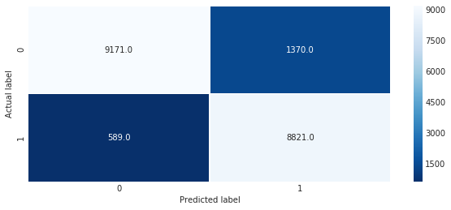

```python
plt.figure(figsize = (10, 4))
sns.heatmap(random_cm, annot=True, fmt=".1f", linewidths=.3, cmap = 'Blues_r')
plt.ylabel('Actual label')
plt.xlabel('Predicted label')
```

### Support Vector Classification with hyperparameter tuning

```python
# defining parameter range
param_grid = {'C': [10, 100, 1000],
              'gamma': [1]
             }
svm_grid = GridSearchCV(SVC(), param_grid, verbose = 3)
svm_grid.fit(X_train, y_train)
```

```
Fitting 3 folds for each of 3 candidates, totalling 9 fits
[CV] C=10, gamma=1 ...................................................
[CV] .......... C=10, gamma=1, score=0.8129269235726253, total=  49.8s
[CV] C=10, gamma=1 ...................................................
```

```
[Parallel(n_jobs=1)]: Done   1 out of   1 | elapsed:  1.1min remaining:    0.0s
```

```
[CV] .......... C=10, gamma=1, score=0.8162541892240268, total=  49.1s
[CV] C=10, gamma=1 ...................................................
```

```
[Parallel(n_jobs=1)]: Done   2 out of   2 | elapsed:  2.3min remaining:    0.0s
```

```
[CV] ........... C=10, gamma=1, score=0.808584686774942, total=  44.7s
[CV] C=100, gamma=1 ..................................................
[CV] ......... C=100, gamma=1, score=0.8765304807320531, total=  45.9s
[CV] C=100, gamma=1 ..................................................
[CV] ......... C=100, gamma=1, score=0.8760634184068059, total=  47.0s
[CV] C=100, gamma=1 ..................................................
[CV] ......... C=100, gamma=1, score=0.8720675431812323, total=  46.1s
[CV] C=1000, gamma=1 .................................................
[CV] ........ C=1000, gamma=1, score=0.8934140997551231, total=  45.3s
[CV] C=1000, gamma=1 .................................................
[CV] ........ C=1000, gamma=1, score=0.8910801753029132, total=  47.8s
[CV] C=1000, gamma=1 .................................................
[CV] ......... C=1000, gamma=1, score=0.891337973704563, total=  51.2s
```

```
[Parallel(n_jobs=1)]: Done   9 out of   9 | elapsed:  9.3min finished
```

```
GridSearchCV(cv=None, error_score='raise',
       estimator=SVC(C=1.0, cache_size=200, class_weight=None, coef0=0.0,
  decision_function_shape='ovr', degree=3, gamma='auto', kernel='rbf',
  max_iter=-1, probability=False, random_state=None, shrinking=True,
  tol=0.001, verbose=False),
       fit_params=None, iid=True, n_jobs=1,
       param_grid={'C': [10, 100, 1000], 'gamma': [1]},
       pre_dispatch='2*n_jobs', refit=True, return_train_score='warn',
       scoring=None, verbose=3)
```

```python
y_pred = svm_grid.predict(X_test)
svm_cr = classification_report(y_test, y_pred)
svm_cm = confusion_matrix(y_test, y_pred)
print(svm_cr)
```

```
             precision    recall  f1-score   support

          0       0.89      0.92      0.90     10541
          1       0.91      0.87      0.89      9410

avg / total       0.90      0.90      0.90     19951
```

```
Text(0.5,18.5,'Predicted label')
```

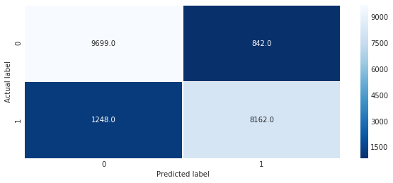

```python
plt.figure(figsize = (10, 4))
sns.heatmap(svm_cm, annot=True, fmt=".1f", linewidths=.3, cmap = 'Blues_r')
plt.ylabel('Actual label')
plt.xlabel('Predicted label')
```

### Gradient Boosting Classifier with hyperparameter tuning

```python
#grad_boost = GradientBoostingClassifier(n_estimators=100, max_depth=3, min_samples_split=2, min_samples_leaf=2)
grad_boost = GradientBoostingClassifier()
param_grid = {
    "learning_rate": [0.1],
    "min_samples_split": [2],
    "min_samples_leaf": [3],
    "max_depth": [3, 5],
    "subsample": [0.95, 0.1],
    "n_estimators":[100, 1000]
    }

grid_boost = GridSearchCV(grad_boost, param_grid, verbose=3)
grid_boost.fit(X_train, y_train)
```

```
Fitting 3 folds for each of 8 candidates, totalling 24 fits
[CV] learning_rate=0.1, max_depth=3, min_samples_leaf=3, min_samples_split=2, n_estimators=100, subsample=0.95
[CV]  learning_rate=0.1, max_depth=3, min_samples_leaf=3, min_samples_split=2, n_estimators=100, subsample=0.95, score=0.9171284959401985, total=   2.7s
[CV] learning_rate=0.1, max_depth=3, min_samples_leaf=3, min_samples_split=2, n_estimators=100, subsample=0.95
```

```
[Parallel(n_jobs=1)]: Done   1 out of   1 | elapsed:    2.8s remaining:    0.0s
```

```
[CV]  learning_rate=0.1, max_depth=3, min_samples_leaf=3, min_samples_split=2, n_estimators=100, subsample=0.95, score=0.91415313225058, total=   2.7s
[CV] learning_rate=0.1, max_depth=3, min_samples_leaf=3, min_samples_split=2, n_estimators=100, subsample=0.95
```

```
[Parallel(n_jobs=1)]: Done   2 out of   2 | elapsed:    5.6s remaining:    0.0s
```

[output not shown]

```
[Parallel(n_jobs=1)]: Done  24 out of  24 | elapsed:  5.9min finished
```

```
GridSearchCV(cv=None, error_score='raise',
       estimator=GradientBoostingClassifier(criterion='friedman_mse', init=None,
              learning_rate=0.1, loss='deviance', max_depth=3,
              max_features=None, max_leaf_nodes=None,
              min_impurity_decrease=0.0, min_impurity_split=None,
              min_samples_leaf=1, min_samples_split=2,
              min_weight_fraction_leaf=0.0, n_estimators=100,
              presort='auto', random_state=None, subsample=1.0, verbose=0,
              warm_start=False),
       fit_params=None, iid=True, n_jobs=1,
       param_grid={'learning_rate': [0.1], 'min_samples_split': [2], 'min_samples_leaf': [3], 'max_depth': [3, 5], 'subsample': [0.95, 0.1], 'n_estimators': [100, 1000]},
       pre_dispatch='2*n_jobs', refit=True, return_train_score='warn',
       scoring=None, verbose=3)
```

```python
y_pred = grid_boost.predict(X_test)
grad_boost_cr = classification_report(y_test, y_pred)
grad_boost_cm = confusion_matrix(y_test, y_pred)
print(grad_boost_cr)
```

```
             precision    recall  f1-score   support

          0       0.94      0.90      0.92     10541
          1       0.89      0.93      0.91      9410

avg / total       0.92      0.92      0.92     19951
```

```
Text(0.5,18.5,'Predicted label')
```

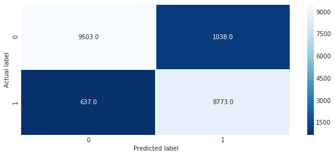

```python
plt.figure(figsize = (10, 4))
sns.heatmap(grad_boost_cm, annot=True, fmt=".1f", linewidths=.3, cmap = 'Blues_r')
plt.ylabel('Actual label')
plt.xlabel('Predicted label')
```

# Model Result Comparison

| Model | Precision | Recall | f1-score |
| --- | --- | --- | --- |
| Logistic Regression (Benchmark) | 0.88 | 0.88 | 0.88 |
| Random Forest Classifier | 0.90 | 0.90 | 0.90 |
| Support Vector Classification (SVC) | 0.90 | 0.90 | 0.90 |
| Gradient Boosting Classifier | 0.92 | 0.92 | 0.92 |

# Analysis

- Precision, Recall and f1-score were all similar which proves models' effericiency.
- Gradient Boosting Classifier performed best with hyperparameter tuning.
- For lack of computation power only several parameter was tuned.
- Though the models were pretty good in predicting offer completion of Starbucks.

# Learning Curve of the best model

```python
def plot_learning_curve(model_str, train_sizes, train_scores, validation_scores):
    '''
    Plotting the learning curve of a machine learning model given the input
    parameters

    Args:
        model_str (str): string model's name
        train_sizes (list): list of training sizes to be calculated
        train_scores (list): training scores of model (metrics)
        validation_scores (list): validation scores of model (metrics)
    Returns:
        None
        *this function plots learning curves with their std bounds
    '''
    figure, ax = plt.subplots(figsize = (8, 6))

    train_scores_mean = train_scores.mean(axis = 1)
    train_scores_std = train_scores.std(axis = 1)
    validation_scores_mean = validation_scores.mean(axis = 1)
    validation_scores_std = validation_scores.std(axis = 1)

    plt.plot(train_sizes, train_scores_mean, label = 'Training Score', marker = 'o', color = 'r')
    plt.fill_between(train_sizes, train_scores_mean - train_scores_std,
                         train_scores_mean + train_scores_std, alpha=0.1,
                         color = "r")
    plt.plot(train_sizes, validation_scores_mean, label = 'Validation Score', marker = 'o', color = 'g')
    plt.fill_between(train_sizes, validation_scores_mean - validation_scores_std,
                         validation_scores_mean + validation_scores_std, alpha=0.1,
                         color = "g")

    plt.ylabel('Accuracy')
    plt.xlabel('Training set size')
    plt.title('Learning curves for ' + str(model_str))
    plt.legend()
    plt.show()


    return
```

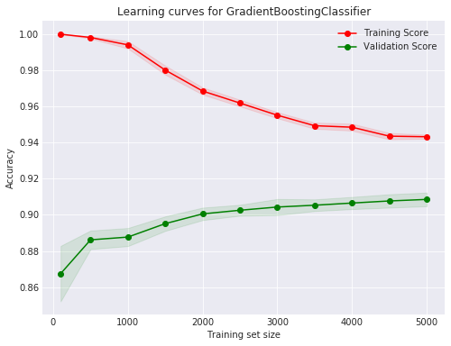

```python
train_sizes = [100, 500, 1000, 1500, 2000, 2500, 3000, 3500, 4000, 4500, 5000]
model = GradientBoostingClassifier(learning_rate=0.1, max_depth=5, min_samples_leaf=3,
                                   min_samples_split=2, n_estimators=100, subsample=0.95)

model.fit(X, y)

train_sizes, train_scores, validation_scores = learning_curve(estimator = model,
                                                              X = X, y = y,
                                                              train_sizes = train_sizes, cv = 10)
plot_learning_curve('GradientBoostingClassifier', train_sizes, train_scores, validation_scores)
```